# Homework 2

[figure not shown]

##### **Authors:** Adrienn Timea Aszalos - Joelelle Coley - Giovanni Giunta - Daniel Jiménez

##### **Date:** 2021/01/17

##### **Subject:** Statistics for Data Science

##### **Data Science Master’s programme**

##### **La Sapienza University of Rome**

In this document, you can find a solution to the second homework proposed.

## Setting environment up

First things first, for you to be able to run this file from R Studio is necessary to have the next packages installed in your PC:

- `mixtools`: Used to handle (fit, generate random samples, etc) mixture models
- `ggplot2`: Used to provide statistical and other plots
- `tictoc`: Used to measure the running time of the executions

## Question 1 (EM fit function for k Mixture of Gaussians -MoG (k can be generic))

To fit a mixture of k Gaussians, we are developing an EM-Algorithm. Using the latter, we manage to estimate the proportions, means and standard deviation of the k desired number of components. Then, the function `handmade.em` will receive the next parameters:

**y:** The data that we will use to fit the mixture.

**p:** the proportion that each of the Gaussians will have. The number of components will be the length of the p vector.

**mu:** a vector corresponding to the starting values for the mean of each Gaussian.

**sigma:** a vector corresponding to the starting values of the standard deviation of each Gaussian.

**n_iter:** The number of iterations that the algorithm will perform.

**plot_flag:** A flag regarding whether to plot the histogram of the mixture or not.

```r
# Handmade EM4MoG ---------------------------------------------------------

handmade.em <- function(y, p, mu, sigma, n_iter, plot_flag = T)
{
  # Define epsilon to avoid zero divisions
  epsilon = 0.001

  # Define colors for plots
  cols     <- c(rgb(1,0,0,.3), rgb(0,1,0,.3))

  # Intitialize likelihood
  like <- 0

  # Get the number of components
  k = length(p)

  prev_deviance <- 0

  # Calculate likelihood
  for (i in 1:k) {
    # Cumulate each time the likelihood of a normal distribution
    like <- like + (p[i] * dnorm(y, mu[i], sigma[i]))
  }

  # Calculate Deviance
  deviance <- -2*sum(log(like))

  # Initialize table with results of each iteration
  res      <- matrix(NA,n_iter + 1, k * 3 + 2)

  # Put in the first cell the initial values
  res[1,]  <- c(0, p, mu, sigma, deviance)


  for (iter in 1:n_iter) {
    # E step
    d <- array(replicate(length(y) * k, 0), dim=c(k, length(y)))
    r <- array(replicate(length(y) * k, 0), dim=c(k, length(y)))

    # Store each normal distribution generated with parameters
    for (i in 1:k) {
      d[i,] <- p[i]*dnorm(y, mu[i], sigma[i])
    }

    # Define the new proportions based on previous normal distributions
    for (i in 1:k) {
      r[i, ] <- d[i, ] / colSums(d)
    }


    # M step
    for (i in 1:k) {
      # Estimate the proportions
      p[i] <- mean(r[i,])

      # Estimate the means
      mu[i]    <- sum(r[i,]*y)/(sum(r[i,])+epsilon)

      # Estimate the standard deviations
      sigma[i] <- sqrt( sum(r[i,]*(y^2))/(sum(r[i,])+epsilon) - (mu[i])^2 )

    }

    # Intitialize likelihood
    like <- 0

    # Calculate likelihood
    for (i in 1:k) {
      like <- like + (p[i] * dnorm(y, mu[i], sigma[i]))
    }

    # Calculate Deviance based on new estimators
    deviance <- -2*sum(log(like))

    # Save in the table the results of the estimations
    res[iter+1,] <- c(iter, p, mu, sigma, deviance)


    # Check if the deviance is null
    if(is.na(deviance)){
      deviance <- 0
      prev_deviance <- 0
    }

    # Configure an early stopping step
    if (abs(prev_deviance - deviance) < 0.0001){
      iter = n_iter
    }

    # Replace previous deviance with new deviance for the next iteration
    prev_deviance <- deviance

    # Plot obtained and real distributions in each iteration
    if (plot_flag){
      hist(y, prob = T, breaks = 30, col = gray(.8), border = NA,
           main = "", xlab = paste("EM Iteration: ", iter, "/", n_iter, sep = ""))
      set.seed(123)
      points(jitter(y), rep(0,length(y)),
             pch = 19, cex = .6,
             col = cols[ (dnorm(y,mu[1],sigma[1]) > dnorm(y,mu[2],sigma[2])) + 1])
      curve(p[1]*dnorm(x,mu[1],sigma[1]) + p[2]*dnorm(x,mu[2],sigma[2]),
            lwd = 4, col = rgb(0,0,0,.5), add = TRUE)
      Sys.sleep(1.5)
    }
  }
  # Convert table of results to data frame
  res <- data.frame(res)

  # Rename the final table
  names(res) <- c("iteration", paste("p",seq(1,k),sep=""), paste("mu",seq(1,k),sep="")
                  , paste("sigma",seq(1,k),sep=""), "deviance")

  # Generate output of the function as a list of values
  out <- list(parameters = c(p = p, mu = mu, sigma = sigma), deviance = deviance, res = res)
  return(out)
}
```

#### The following example uses the generic EM fit function for k = 2.

```
## $parameters
##         p1         p2        mu1        mu2     sigma1     sigma2
##  0.3562881  0.6437119 54.4656615 79.9909049  5.7515000  5.9729405
##
## $deviance
## [1] 2068.116
##
## $res
##    iteration        p1        p2      mu1      mu2   sigma1    sigma2
## 1          0 0.5000000 0.5000000 45.00000 55.00000 8.000000  8.000000
## 2          1 0.1364418 0.8635582 53.12254 73.70488 7.535024 12.104013
## 3          2 0.1621634 0.8378366 52.34215 74.48781 5.262664 11.616213
## 4          3 0.1964745 0.8035255 51.89983 75.54159 4.409119 10.707191
## 5          4 0.2269476 0.7730524 51.80079 76.50260 4.194467  9.726519
## 6          5 0.2515590 0.7484410 51.98294 77.25366 4.231524  8.911636
```

[output cut: 27 more lines]

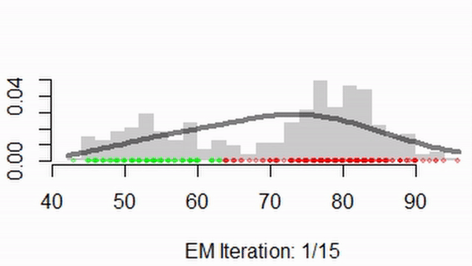

```r
# Test if the function is estimating correctly the parameters
data("faithful")
handmade.em(faithful$waiting,
                       p      = c(.5,.5),
                       mu     = c(45,55),
                       sigma  = c(8,8),
                       n_iter = 15,
                       plot_flag = F)
```

In the previous gif, we can see that in each iteration that the handmade function based on the EM algorithm generates estimated values that look similar to the real distribution of the data used, in each iteration. Thus, we concluded that the function created is working properly.

## Question 2

Now we will test the performance of a random normal mixture distribution with a small sample size ($n = 50$). To achieve, that we used some tools provided by the package `mixtools`.

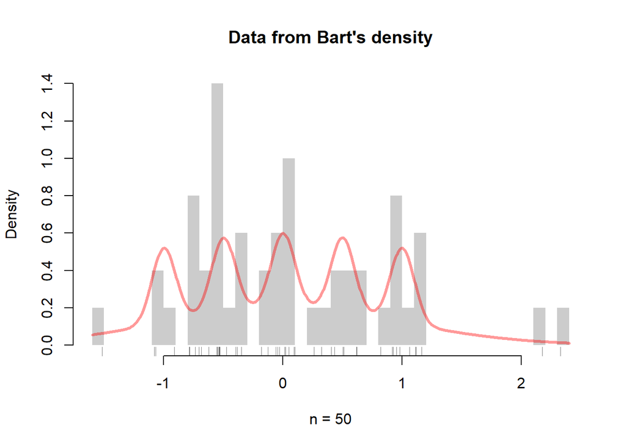

```r
suppressWarnings(suppressMessages(require(mixtools, quietly = T)))
suppressWarnings(suppressMessages(require(caret, quietly = T)))
suppressWarnings(suppressMessages(require(tictoc, quietly = T)))
suppressWarnings(suppressMessages(require(mclust, quietly = T)))
suppressWarnings(suppressMessages(require(KScorrect, quietly = T)))

options(scipen=999)
n <- 50 # Sample size
XX <- rnormmix(n,
lambda = c(0.5, rep(0.1,5)), mu = c(0, ((0:4)/2)-1), sigma = c(1, rep(0.1,5)) )
# Make an histogram of the data
hist(XX, prob = T, col = gray(.8), border = NA,
main = paste("Data from Bart's density",sep=""), xlab = paste("n = ", n, sep = ""),
breaks = 50)
# Show the data points
rug(XX, col = rgb(0,0,0,.5))
# Plot the true density
true.den = function(x) 0.5*dnorm(x, 0, 1) + 0.1*dnorm(x,-1.0, 0.1) + 0.1*dnorm(x, -0.5, 0.1) + 0.1*dnorm(x, 0.0, 0.1) + 0.1*dnorm(x, 0.5, 0.1) +
0.1*dnorm(x, 1.0, 0.1)
curve(true.den, col = rgb(1,0,0,0.4), lwd = 3, n = 500, add = TRUE)
```

Clearly, with the previous chart, we can say that using a small sample there is a non-asymptotic shape for the Bart distribution. The previous means that the sampled data points do not seem to follow the distribution curve.

Now we will test the same functions used before but using a sample size of 1000 points.

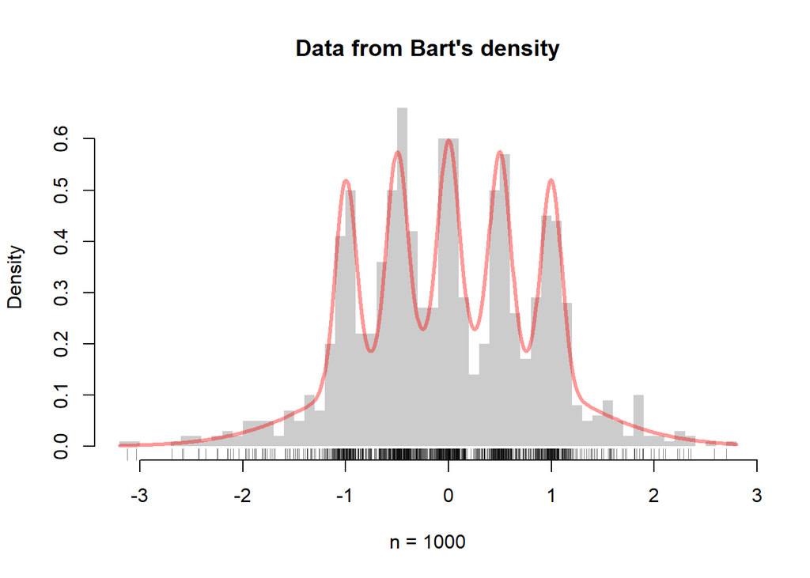

```r
suppressWarnings(suppressMessages(require(mixtools, quietly = T))) # Package and function ?rnormmix
options(scipen=999)
n <- 1000 # Sample size
XX <- rnormmix(n,
lambda = c(0.5, rep(0.1,5)), mu = c(0, ((0:4)/2)-1), sigma = c(1, rep(0.1,5)) )
# Make an histogram of the data
hist(XX, prob = T, col = gray(.8), border = NA,
main = paste("Data from Bart's density",sep=""), xlab = paste("n = ", n, sep = ""),
breaks = 50)
# Show the data points
rug(XX, col = rgb(0,0,0,.5))
# Plot the true density
true.den = function(x) 0.5*dnorm(x, 0, 1) + 0.1*dnorm(x,-1.0, 0.1) + 0.1*dnorm(x, -0.5, 0.1) + 0.1*dnorm(x, 0.0, 0.1) + 0.1*dnorm(x, 0.5, 0.1) +
0.1*dnorm(x, 1.0, 0.1)
curve(true.den, col = rgb(1,0,0,0.4), lwd = 3, n = 500, add = TRUE)
```

Now, with the obtained figures we can see a reasonably asymptotic for the Bart distribution. The sampled data points match the Bart distribution. And if we continue to grow the sample size, the sampled distribution looks more similar to The Bart each time.

## Question 3

To solve the third exercise, we define the next function to calculate the log-likelihood given some data and the parameters estimated by the `handmade.em`. That likelihood will be the metric to compare and define the best number of components.

```r
# Function to calculate the log-likelihood from given data and parameters
log_like <- function(data, fit){
  # data: Data used to fit the distribution
  # fit: Object that contains the result of the application of the handmade.em function

  # Extract the number of components
  k <- length(fit$parameters) / 3

  # Extract the proportions
  ps <- fit$parameters[1:k]

  # Extract the estimations for the mean (mu)
  mus <- fit$parameters[(k+1):(k+k)]

  # Extract the estimations for the standard deviation (sigma)
  sigmas <- fit$parameters[(k+k+1):(k+k+k)]

  # Compute the likelihood
  like <- 0
  for (i in 1:k) {
    like <- like + (ps[i] * dnorm(data, mus[i], sigmas[i]))
  }

  # Compute the log-likelihood
  log_like <- log(like)

  return(log_like)
}
```

### a)

With the next chunk of code, we apply the AIC model selection method to estimate the optimum k, number of components. To avoid a double calculation, we also computed the BIC from the same data. In this first case, we use a sample size of 50.

```r
# Starting time
tictoc::tic()

# Define the desired number of iterations
M <- 500

# Define the seed for replicability
seed <- 1234

# Define the sample size
n <- 50

# Define the maximum number of components
k_max <- 10

# Pre-allocate memory for the optimum component in each iteration
best_k_n1_aic <- rep(NA,M)
best_k_n1_bic <- rep(NA,M)

# Simulate M times
for(i in 1:M){

  # Simulate from The Bart
  set.seed(seed)
  XX <- rnormmix(n,
                 lambda = c(0.5, rep(0.1,5)), mu = c(0, ((0:4)/2)-1), sigma = c(1, rep(0.1,5)) )

  # Pre-allocate memory for the optimum component in each iteration
  aic_values <- rep(NA,k_max)
  bic_values <- rep(NA,k_max)

  for(j in 1:k_max){

    # Define proportions
    ps <- rep(1,j) / j

    # Define mean values
    set.seed(seed)

    # Generating k random numbers between 0 and 1 and rounding them
    mus <- round(runif(j),0)

    # Define sigma values
    set.seed(seed)
    sigmas <- round(runif(j),1) + 0.1

    # Estimating the three parameters using the XX values
    fit <- handmade.em(XX, p = ps, mu = mus, sigma = sigmas, n_iter = 15, plot_flag = F)

    # Compute AIC & BIC values to  estimates the optimum value of k
    aic_values[j] = fit$deviance + 2*j*3  # Multiplying by 3 which is the number of parameters

    bic_values[j] = fit$deviance + j*log(n)  # Multiplying by 3 which is the number of parameters

    seed <- seed + 100
  }

  # Calculate the position of the best AIC
  best_k_n1_aic[i] <- which.min(aic_values)
  # Calculate the position of the best AIC
  best_k_n1_bic[i] <- which.min(bic_values)

  seed <- seed + 100

}

# Ending time
tictoc::toc()
```

```
## 28.64 sec elapsed
```

```r
summary(best_k_n1_aic)
```

```
##    Min. 1st Qu.  Median    Mean 3rd Qu.    Max.
##   1.000   1.000   1.000   1.248   1.000   6.000
```

```
## [1] "Standard deviation: 0.65"
```

```
## [1] "Coefficient of variation (CV): 51.89%"
```

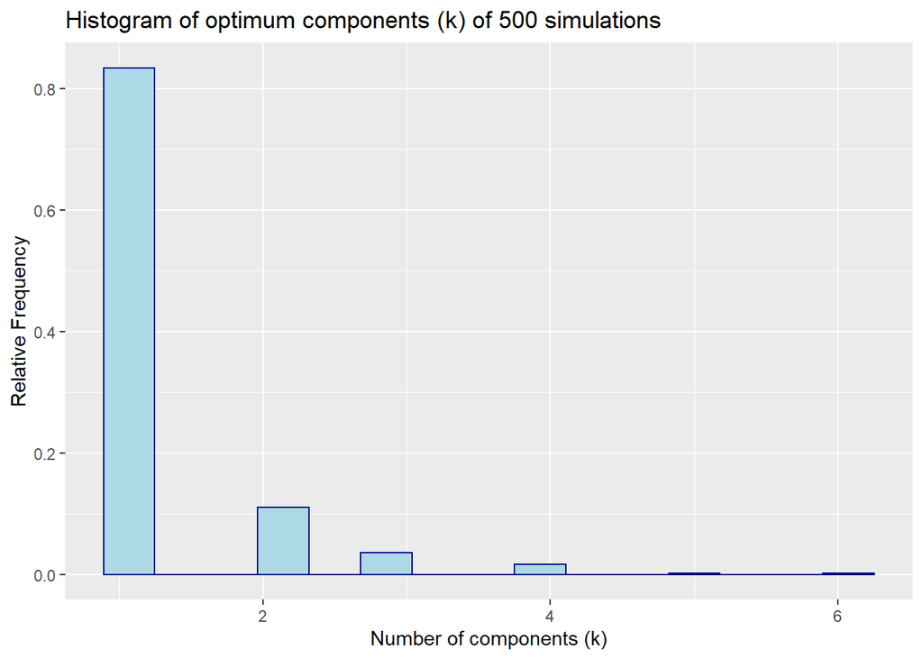

```r
ggplot2::ggplot(data.frame(best_k_n1_aic), ggplot2::aes(x=best_k_n1_aic))+
  ggplot2::geom_histogram(ggplot2::aes(y=..count../sum(..count..)), color="darkblue", fill="lightblue", bins =15)+
  ggplot2::labs(title = paste("Histogram of optimum components (k) of ", M, " simulations", sep=""), y = "Relative Frequency", x = "Number of components (k)")
```

Now we execute the same process, using a sample size of 1000.

```r
# Starting time
tictoc::tic()

# Define the desired number of iterations
M <- 500

# Define the seed for replicability
seed <- 1234

# Define the sample size
n <- 1000

# Define the maximum number of components
k_max <- 10

# Pre-allocate memory for the optimum component in each iteration
best_k_n2_aic <- rep(NA,M)
best_k_n2_bic <- rep(NA,M)

# Simulate M times
for(i in 1:M){

  # Simulate from The Bart
  set.seed(seed)
  XX <- rnormmix(n,
                 lambda = c(0.5, rep(0.1,5)), mu = c(0, ((0:4)/2)-1), sigma = c(1, rep(0.1,5)) )

  # Pre-allocate memory for the optimum component in each iteration
  aic_values <- rep(NA,k_max)
  bic_values <- rep(NA,k_max)

  for(j in 1:k_max){

    # Define proportions
    ps <- rep(1,j) / j

    # Define mean values
    set.seed(seed)

    # Generating k random numbers between 0 and 1 and rounding them
    mus <- round(runif(j),0)

    # Define sigma values
    set.seed(seed)
    sigmas <- round(runif(j),1) + 0.1

    # Estimating the three parameters using the XX values
    fit <- handmade.em(XX, p = ps, mu = mus, sigma = sigmas, n_iter = 15, plot_flag = F)

    # Compute AIC & BIC values to  estimates the optimum value of k
    aic_values[j] = fit$deviance + 2*j*3  # Multiplying by 3 which is the number of parameters

    bic_values[j] = fit$deviance + j*log(n)  # Multiplying by 3 which is the number of parameters

    seed <- seed + 100
  }

  # Calculate the position of the best AIC
  best_k_n2_aic[i] <- which.min(aic_values)
  # Calculate the position of the best AIC
  best_k_n2_bic[i] <- which.min(bic_values)

  seed <- seed + 100

}

# Ending time
tictoc::toc()
```

```
## 388.23 sec elapsed
```

```r
summary(best_k_n2_aic)
```

```
##    Min. 1st Qu.  Median    Mean 3rd Qu.    Max.
##   1.000   4.000   5.000   5.162   7.000  10.000
```

```
## [1] "Standard deviation: 2.38"
```

```
## [1] "Coefficient of variation (CV): 46.07%"
```

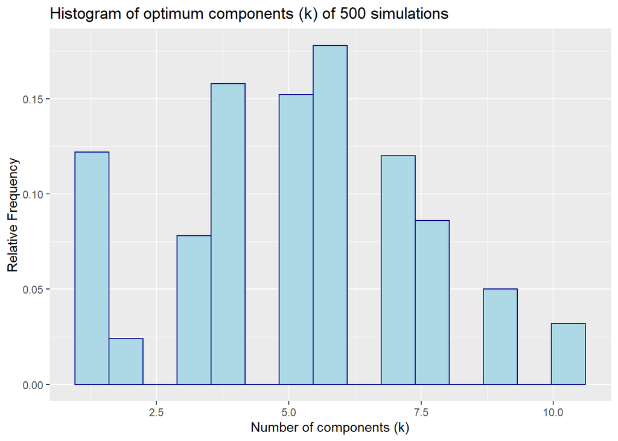

```r
ggplot2::ggplot(data.frame(best_k_n2_aic), ggplot2::aes(x=best_k_n2_aic))+
  ggplot2::geom_histogram(ggplot2::aes(y=..count../sum(..count..)), color="darkblue", fill="lightblue", bins =15)+
  ggplot2::labs(title = paste("Histogram of optimum components (k) of ", M, " simulations", sep=""), y = "Relative Frequency", x = "Number of components (k)")
```

In this case, when using the AIC as a metric to choose the number of components, its distributions are quite symmetric. Besides, the values are around 5 (close to the real components). And the coefficient of variation is not high at all.

### b)

As we ran the BIC in the previous literal, we only plot here its distribution when using a sample size of 50.

```r
summary(best_k_n1_bic)
```

```
##    Min. 1st Qu.  Median    Mean 3rd Qu.    Max.
##   1.000   1.000   1.000   1.788   2.000   9.000
```

```
## [1] "Standard deviation: 1.39"
```

```
## [1] "Coefficient of variation (CV): 77.88%"
```

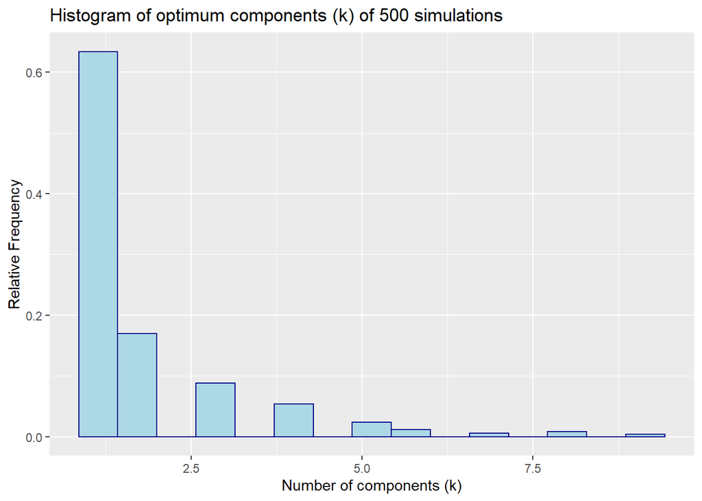

```r
ggplot2::ggplot(data.frame(best_k_n1_bic), ggplot2::aes(x=best_k_n1_bic))+
  ggplot2::geom_histogram(ggplot2::aes(y=..count../sum(..count..)), color="darkblue", fill="lightblue", bins =15)+
  ggplot2::labs(title = paste("Histogram of optimum components (k) of ", M, " simulations", sep=""), y = "Relative Frequency", x = "Number of components (k)")
```

As happened with the AIC, the number of components is close to 1. That behaviour is mainly caused due to the small sample size taken.

Now we analyze the distribution of the optimum values selected from a sample size of 1000 and using the BIC.

```r
summary(best_k_n2_bic)
```

```
##    Min. 1st Qu.  Median    Mean 3rd Qu.    Max.
##   1.000   3.000   5.000   4.574   6.000  10.000
```

```
## [1] "Standard deviation: 2.46"
```

```
## [1] "Coefficient of variation (CV): 53.84%"
```

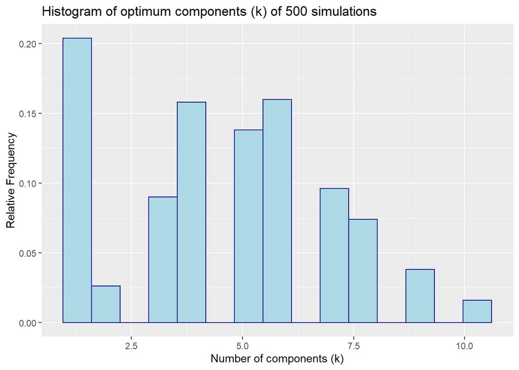

```r
ggplot2::ggplot(data.frame(best_k_n2_bic), ggplot2::aes(x=best_k_n2_bic))+
  ggplot2::geom_histogram(ggplot2::aes(y=..count../sum(..count..)), color="darkblue", fill="lightblue", bins =15)+
  ggplot2::labs(title = paste("Histogram of optimum components (k) of ", M, " simulations", sep=""), y = "Relative Frequency", x = "Number of components (k)")
```

Looking at the previous information, we can see how the distribution of the number of components is not that symmetric as the AIC, but mean the number of components is also close to 5. Also, the variation is around 53%.

### c)

To execute this simulation we defined a function that generates some data from The Bart and calculate the optimum number of components based on a train / test schema. The function goes as follows:

```r
sample_splitting <- function(seed, k_max, M, Z, n, p) {
  # seed: Seed for replicability
  # k_max: Maximum number of components to be considered
  # M: Number of iterations for the simulation
  # Z: Maximum number of iterations for the EM algorithm
  # n: Sample size
  # p: Proportion to split the data in train

  best_M <- rep(NA,M)

  for (i in 1:M) {

    # Update the seed
    seed <- seed + 100
    set.seed(seed)

    # Create dataset
    XX <- rnormmix(n, lambda=c(0.5,rep(0.1,5)), mu=c(0, ((0:4)/2)-1), sigma=c(1,rep(0.1,5)) )

    # Split data into training sample and test sample according to parameter "p"
    trainIndex <- createDataPartition(XX, p=p, list=FALSE)

    train_sample <- XX[trainIndex] # why not XX[trainIndex,] ???
    test_sample <- XX[-trainIndex] # why not XX[-trainIndex,] ???

    log_like_k <- rep(NA,k_max)

    for (k in 1:k_max) {

      # Update the seed
      seed <- seed + 100
      set.seed(seed)

      ps <- rep(1,k) / k

      # Define values for mu and sigma
      mus <- round(runif(k),0)
      sigmas <- round(runif(k),1) + 0.1

      # Fit the training data to estimate the parameters
      fit <- handmade.em(train_sample, p=ps, mu=mus, sigma=sigmas, n_iter=Z, plot_flag=F)

      # Apply the log-likelihood estimation over the test data
      log_like_k[k] <- sum(log_like(test_sample, fit))

    }
    best_M[i] <- which.max(log_like_k)
  }

  return(best_M)
}
```

Now we can execute the previous function to select the number of optimum components based on splitting in train = 50% and test = 50%, using the sample size of 50.

```r
tictoc::tic()

# Define the desired number of iterations
M <- 500

# Set number of iterations for the handmade EM function
Z <- 15

# Define the seed for replicability
seed <- 1234

# Define the maximum number of components
k_max <- 10

# Define the sample size
n <- 50

best_k_n1_Tr50_Te50 <- sample_splitting(seed, k_max, M, Z, n = n, p = 0.5)

tictoc::toc()
```

```
## 19.89 sec elapsed
```

```r
summary(best_k_n1_Tr50_Te50)
```

```
##    Min. 1st Qu.  Median    Mean 3rd Qu.    Max.
##   1.000   1.000   3.000   3.838   6.000  10.000
```

```
## [1] "Standard deviation: 2.96"
```

```
## [1] "Coefficient of variation (CV): 77.21%"
```

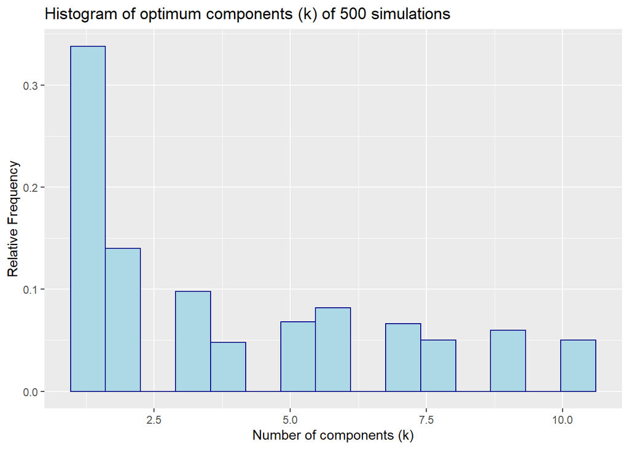

```r
ggplot2::ggplot(data.frame(best_k_n1_Tr50_Te50), ggplot2::aes(x=best_k_n1_Tr50_Te50))+
  ggplot2::geom_histogram(ggplot2::aes(y=..count../sum(..count..)), color="darkblue", fill="lightblue", bins =15)+
  ggplot2::labs(title = paste("Histogram of optimum components (k) of ", M, " simulations", sep=""), y = "Relative Frequency", x = "Number of components (k)")
```

Next step is to use the function to select the number of optimum components based on splitting in train = 50% and test = 50%, using the sample size of 1000.

```r
tictoc::tic()

# Define the desired number of iterations
M <- 500

# Set number of iterations for the handmade EM function
Z <- 15

# Define the seed for replicability
seed <- 1234

# Define the maximum number of components
k_max <- 10

# Define the sample size
n <- 1000

best_k_n2_Tr50_Te50 <- sample_splitting(seed, k_max, M, Z, n = n, p = 0.5)

tictoc::toc()
```

```
## 201.85 sec elapsed
```

```r
summary(best_k_n2_Tr50_Te50)
```

```
##    Min. 1st Qu.  Median    Mean 3rd Qu.    Max.
##   1.000   7.000   8.000   7.784   9.000  10.000
```

```
## [1] "Standard deviation: 1.99"
```

```
## [1] "Coefficient of variation (CV): 25.53%"
```

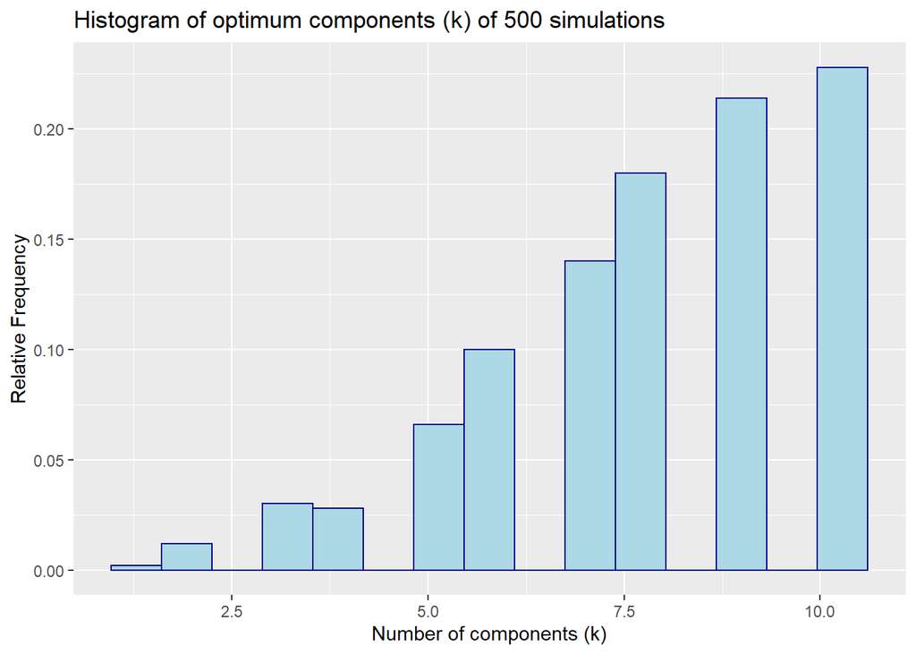

```r
ggplot2::ggplot(data.frame(best_k_n2_Tr50_Te50), ggplot2::aes(x=best_k_n2_Tr50_Te50))+
  ggplot2::geom_histogram(ggplot2::aes(y=..count../sum(..count..)), color="darkblue", fill="lightblue", bins =15)+
  ggplot2::labs(title = paste("Histogram of optimum components (k) of ", M, " simulations", sep=""), y = "Relative Frequency", x = "Number of components (k)")
```

Clearly, the distribution of k is left heavy-tailed. In this case, the average number of components is 7 (closer to the real one that is 6). Besides, the variation of those points is very low (near to 26%).

### d)

Now we can execute the function defined in the previous literal to select the number of optimum components based on splitting in train = 70% and test = 30%, using the sample size of 50.

```r
tictoc::tic()

# Define the desired number of iterations
M <- 500

# Set number of iterations for the handmade EM function
Z <- 15

# Define the seed for replicability
seed <- 1234

# Define the maximum number of components
k_max <- 10

# Define the sample size
n <- 50

best_k_n1_Tr70_Te30 <- sample_splitting(seed, k_max, M, Z, n = n, p = 0.7)

tictoc::toc()
```

```
## 24.66 sec elapsed
```

```r
summary(best_k_n1_Tr70_Te30)
```

```
##    Min. 1st Qu.  Median    Mean 3rd Qu.    Max.
##   1.000   2.000   5.000   4.786   7.250  10.000
```

```
## [1] "Standard deviation: 3.11"
```

```
## [1] "Coefficient of variation (CV): 65.06%"
```

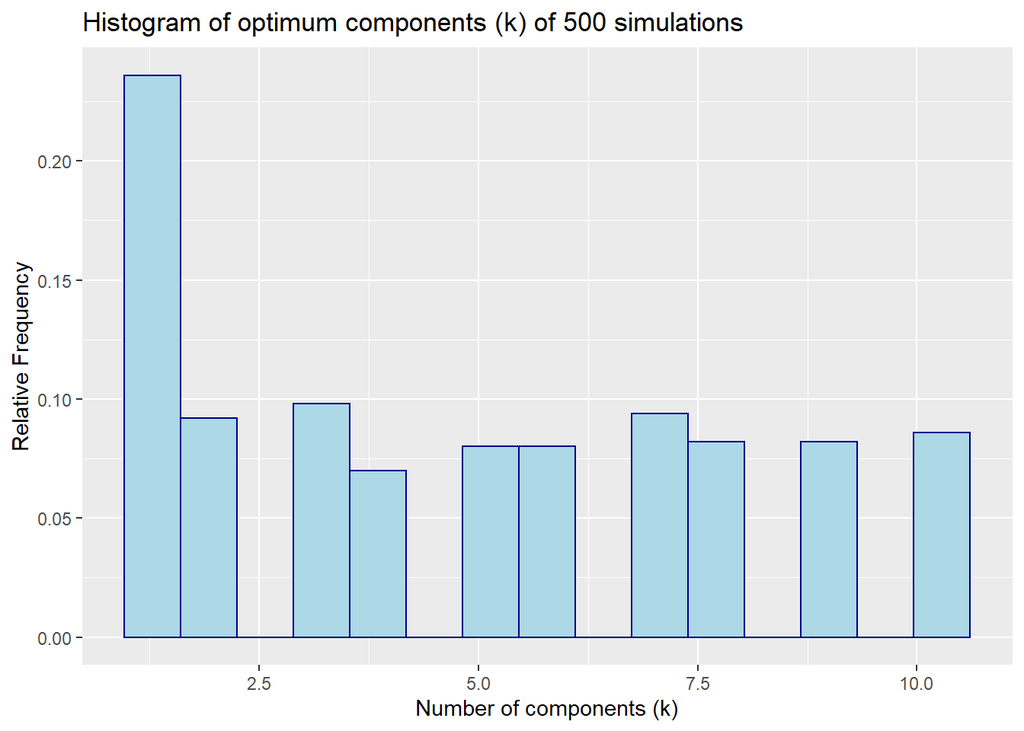

```r
ggplot2::ggplot(data.frame(best_k_n1_Tr70_Te30), ggplot2::aes(x=best_k_n1_Tr70_Te30))+
  ggplot2::geom_histogram(ggplot2::aes(y=..count../sum(..count..)), color="darkblue", fill="lightblue", bins =15)+
  ggplot2::labs(title = paste("Histogram of optimum components (k) of ", M, " simulations", sep=""), y = "Relative Frequency", x = "Number of components (k)")
```

In this case, the optimum components mean is 5. But, the coefficient of variation is quite high (64%). Although the distribution has many occurrences near to the value 1, the remaining components (from 2 to 10) have higher participation compared to the previous literals.

Next step is to use the function to select the number of optimum components based on splitting in train = 70% and test = 30%, using the sample size of 1000.

```r
tictoc::tic()

# Define the desired number of iterations
M <- 500

# Set number of iterations for the handmade EM function
Z <- 15

# Define the seed for replicability
seed <- 1234

# Define the maximum number of components
k_max <- 10

# Define the sample size
n <- 1000

best_k_n2_Tr70_Te30 <- sample_splitting(seed, k_max, M, Z, n = n, p = 0.7)

tictoc::toc()
```

```
## 276.18 sec elapsed
```

```r
summary(best_k_n2_Tr70_Te30)
```

```
##    Min. 1st Qu.  Median    Mean 3rd Qu.    Max.
##   1.000   6.000   8.000   7.656   9.250  10.000
```

```
## [1] "Standard deviation: 2.2"
```

```
## [1] "Coefficient of variation (CV): 28.78%"
```

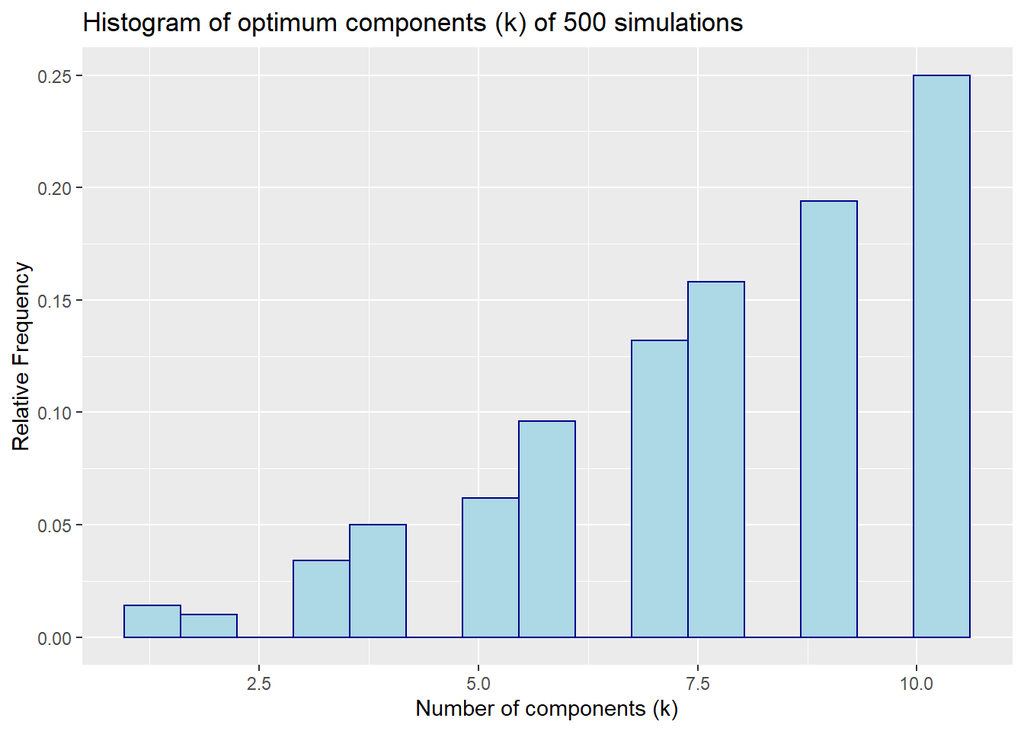

```r
ggplot2::ggplot(data.frame(best_k_n2_Tr70_Te30), ggplot2::aes(x=best_k_n2_Tr70_Te30))+
  ggplot2::geom_histogram(ggplot2::aes(y=..count../sum(..count..)), color="darkblue", fill="lightblue", bins =15)+
  ggplot2::labs(title = paste("Histogram of optimum components (k) of ", M, " simulations", sep=""), y = "Relative Frequency", x = "Number of components (k)")
```

The distribution of k has now many values close to 10. In this case, the main number of components is 8. Besides, the variation of those points is still low (near to 27%).

### e)

We can execute the function defined in the literal c) to select the number of optimum components based on splitting in train = 30% and test = 70%, using the sample size of 50.

```r
tictoc::tic()

# Define the desired number of iterations
M <- 500

# Set number of iterations for the handmade EM function
Z <- 15

# Define the seed for replicability
seed <- 1234

# Define the maximum number of components
k_max <- 10

# Define the sample size
n <- 50

best_k_n1_Tr30_Te70 <- sample_splitting(seed, k_max, M, Z, n = n, p = 0.3)

tictoc::toc()
```

```
## 15.22 sec elapsed
```

```r
summary(best_k_n1_Tr30_Te70)
```

```
##    Min. 1st Qu.  Median    Mean 3rd Qu.    Max.
##     1.0     1.0     1.0     2.5     3.0    10.0
```

```
## [1] "Standard deviation: 2.4"
```

```
## [1] "Coefficient of variation (CV): 95.88%"
```

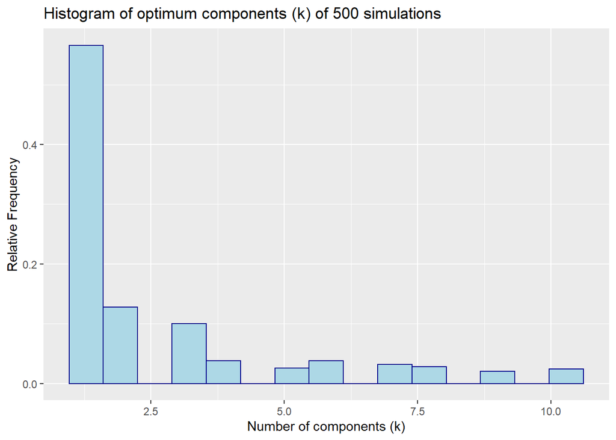

```r
ggplot2::ggplot(data.frame(best_k_n1_Tr30_Te70), ggplot2::aes(x=best_k_n1_Tr30_Te70))+
  ggplot2::geom_histogram(ggplot2::aes(y=..count../sum(..count..)), color="darkblue", fill="lightblue", bins =15)+
  ggplot2::labs(title = paste("Histogram of optimum components (k) of ", M, " simulations", sep=""), y = "Relative Frequency", x = "Number of components (k)")
```

In this case, the number of components near 1 is considerably high. The average value is close to 2 components, and the variation is the highest that we have seen so far (94%).

Next step is to use the function to select the number of optimum components based on splitting in train = 30% and test = 70%, using the sample size of 1000.

```r
tictoc::tic()

# Define the desired number of iterations
M <- 500

# Set number of iterations for the handmade EM function
Z <- 15

# Define the seed for replicability
seed <- 1234

# Define the maximum number of components
k_max <- 10

# Define the sample size
n <- 1000

best_k_n2_Tr30_Te70 <- sample_splitting(seed, k_max, M, Z, n = n, p = 0.3)

tictoc::toc()
```

```
## 124.77 sec elapsed
```

```r
summary(best_k_n2_Tr30_Te70)
```

```
##    Min. 1st Qu.  Median    Mean 3rd Qu.    Max.
##   1.000   6.000   8.000   7.566   9.000  10.000
```

```
## [1] "Standard deviation: 2.22"
```

```
## [1] "Coefficient of variation (CV): 29.4%"
```

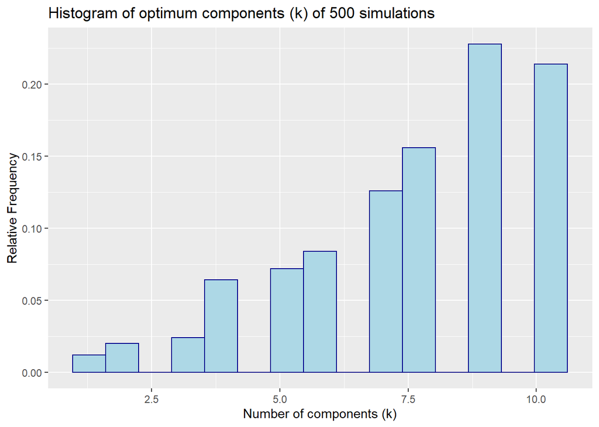

```r
ggplot2::ggplot(data.frame(best_k_n2_Tr30_Te70), ggplot2::aes(x=best_k_n2_Tr30_Te70))+
  ggplot2::geom_histogram(ggplot2::aes(y=..count../sum(..count..)), color="darkblue", fill="lightblue", bins =15)+
  ggplot2::labs(title = paste("Histogram of optimum components (k) of ", M, " simulations", sep=""), y = "Relative Frequency", x = "Number of components (k)")
```

The behaviour of the optimum components this time tends to have many values in higher k. The mean value is close to 7, and the variation is just 29% (it deviates like 2 components on average from the mean).

### f)

To solve this and the next literal, we implemented our cross-validation process. That can be seen in the next function.

```r
# Function that executes the cross-validation process
cross_val <-function(data, folds, seed, k){
  # data: Data to calculate the cross-validations
  # folds: Number of folds desired
  # seed: Random seed to get reproducible results
  # k: Number of components to use

  # Create the folds
  set.seed(seed)
  folds_from_data <- createFolds(data, k = folds)

  # Pre-allocate memory for the log likelihood values in each fold
  loglike_all <- rep(NA,folds)
  for(i in 1:folds){

    # Define proportions
    ps <- rep(1,k) / k

    # Define mean values
    set.seed(seed)
    mus <- round(runif(k,min = -1,max = 1),0)

    # Define sigma values
    set.seed(seed)
    sigmas <- round(runif(k,min = 0.1, max = 1),1)

    # Get train and test data
    train <- data[unlist(folds_from_data[-i], use.names=FALSE)]
    test <- data[-unlist(folds_from_data[-i], use.names=FALSE)]

    # Fit using the selected folds
    fit <- handmade.em(train, p = ps, mu = mus, sigma = sigmas, n_iter = 15, plot_flag = F)

    # Calculate log-likelihood with remaining fold
    loglike_all[i] <- sum(log_like(test, fit))
  }

  # Summarize result of cross validation
  mean_loglike <- mean(loglike_all, na.rm = T)

  return(mean_loglike)
}
```

Now we proceed to determine the optimum number of components based on a 5-fold cross-validation approach. The first run is made with a sample size of 50.

```r
tictoc::tic()
# Define the desired number of iterations
M <- 500

# Define the seed for replicability
seed <- 1234

# Define the sample size
n <- 50

# Define the maximum number of components
k_max <- 10

# Define the number of folds
n_folds <- 5


# Pre-allocate memory for the optimum component in each iteration
best_k_n1_5cv <- rep(NA,M)

# Loop over desired number of iterations
for(i in 1:M){
  # Simulate from The Bart
  set.seed(seed)
  XX <- rnormmix(n,
                 lambda = c(0.5, rep(0.1,5)), mu = c(0, ((0:4)/2)-1), sigma = c(1, rep(0.1,5)) )

  # Set the possible components to check
  k <- 1:k_max
  # Pre-allocate memory for the optimum component in each iteration
  log_like_cross <- rep(NA,k_max)
  for(j in 1:k_max){
    log_like_cross[j] <- cross_val(XX, n_folds, seed, j)
    seed <- seed + 100
  }

  best_k_n1_5cv[i] <- which.max(log_like_cross)

  seed <- seed + 100
}
tictoc::toc()
```

```
## 125.09 sec elapsed
```

```r
summary(best_k_n1_5cv)
```

```
##    Min. 1st Qu.  Median    Mean 3rd Qu.    Max.
##   1.000   1.000   3.000   3.658   6.000  10.000
```

```
## [1] "Standard deviation: 2.87"
```

```
## [1] "Coefficient of variation (CV): 78.44%"
```

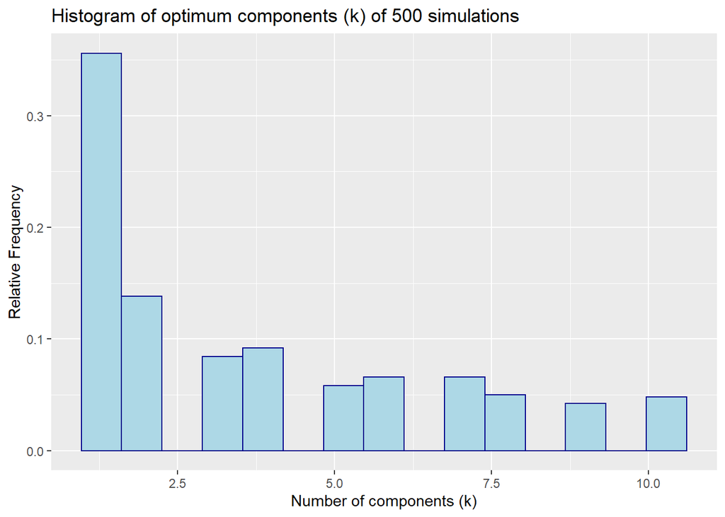

```r
ggplot2::ggplot(data.frame(best_k_n1_5cv), ggplot2::aes(x=best_k_n1_5cv))+
  ggplot2::geom_histogram(ggplot2::aes(y=..count../sum(..count..)), color="darkblue", fill="lightblue", bins =15)+
  ggplot2::labs(title = paste("Histogram of optimum components (k) of ", M, " simulations", sep=""), y = "Relative Frequency", x = "Number of components (k)")
```

Using 5-fold cross-validation leads an asymmetric distribution with many components near to 1. The mean value es 3 and it has a high variability (close to 80%).

The second run is made with a sample size of 1000.

```r
tictoc::tic()
# Define the desired number of iterations
M <- 500

# Define the seed for replicability
seed <- 1234

# Define the sample size
n <- 1000

# Define the maximum number of components
k_max <- 10

# Define the number of folds
n_folds <- 5


# Pre-allocate memory for the optimum component in each iteration
best_k_n2_5cv <- rep(NA,M)

# Loop over desired number of iterations
for(i in 1:M){
  # Simulate from The Bart
  set.seed(seed)
  XX <- rnormmix(n,
                 lambda = c(0.5, rep(0.1,5)), mu = c(0, ((0:4)/2)-1), sigma = c(1, rep(0.1,5)) )

  # Set the possible components to check
  k <- 1:k_max
  # Pre-allocate memory for the optimum component in each iteration
  log_like_cross <- rep(NA,k_max)
  for(j in 1:k_max){
    log_like_cross[j] <- cross_val(XX, n_folds, seed, j)
    seed <- seed + 100
  }

  best_k_n2_5cv[i] <- which.max(log_like_cross)

  seed <- seed + 100
}
tictoc::toc()
```

```
## 1523.52 sec elapsed
```

```r
summary(best_k_n2_5cv)
```

```
##    Min. 1st Qu.  Median    Mean 3rd Qu.    Max.
##   1.000   7.000   9.000   8.218  10.000  10.000
```

```
## [1] "Standard deviation: 1.88"
```

```
## [1] "Coefficient of variation (CV): 22.86%"
```

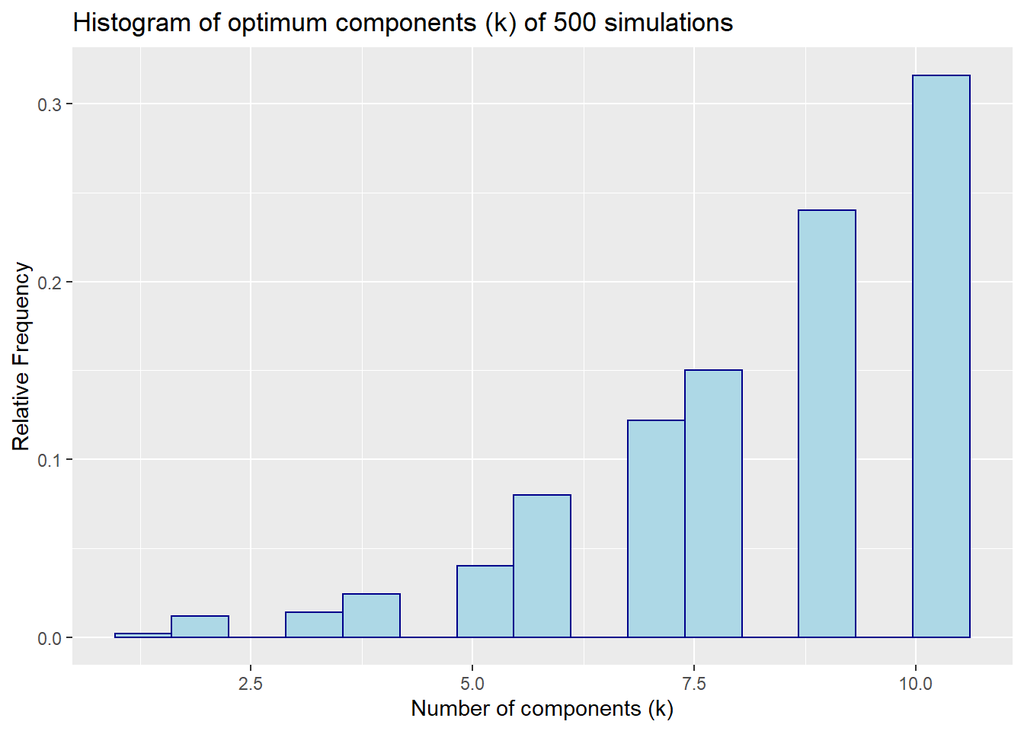

```r
ggplot2::ggplot(data.frame(best_k_n2_5cv), ggplot2::aes(x=best_k_n2_5cv))+
  ggplot2::geom_histogram(ggplot2::aes(y=..count../sum(..count..)), color="darkblue", fill="lightblue", bins =15)+
  ggplot2::labs(title = paste("Histogram of optimum components (k) of ", M, " simulations", sep=""), y = "Relative Frequency", x = "Number of components (k)")
```

When increasing the sample size, the distribution now seems left heavy-tailed. It presents a mean of 8 components (the highest so far) and a small variation of 22%.

### g)

Now that we have performed the analysis using 5-fold cross-validation, we can extend the same approach but using 10 folds. Again, the first run is made with a sample size of 50.

```r
tictoc::tic()
# Define the desired number of iterations
M <- 500

# Define the seed for replicability
seed <- 1234

# Define the sample size
n <- 50

# Define the maximum number of components
k_max <- 10

# Define the number of folds
n_folds <- 10


# Pre-allocate memory for the optimum component in each iteration
best_k_n1_10cv <- rep(NA,M)

# Loop over desired number of iterations
for(i in 1:M){
  # Simulate from The Bart
  set.seed(seed)
  XX <- rnormmix(n,
                 lambda = c(0.5, rep(0.1,5)), mu = c(0, ((0:4)/2)-1), sigma = c(1, rep(0.1,5)) )

  # Set the possible components to check
  k <- 1:k_max
  # Pre-allocate memory for the optimum component in each iteration
  log_like_cross <- rep(NA,k_max)
  for(j in 1:k_max){
    log_like_cross[j] <- cross_val(XX, n_folds, seed, j)
    seed <- seed + 100
  }

  best_k_n1_10cv[i] <- which.max(log_like_cross)

  seed <- seed + 100
}
tictoc::toc()
```

```
## 257.6 sec elapsed
```

```r
summary(best_k_n1_10cv)
```

```
##    Min. 1st Qu.  Median    Mean 3rd Qu.    Max.
##   1.000   1.000   2.000   3.432   5.000  10.000
```

```
## [1] "Standard deviation: 2.81"
```

```
## [1] "Coefficient of variation (CV): 81.78%"
```

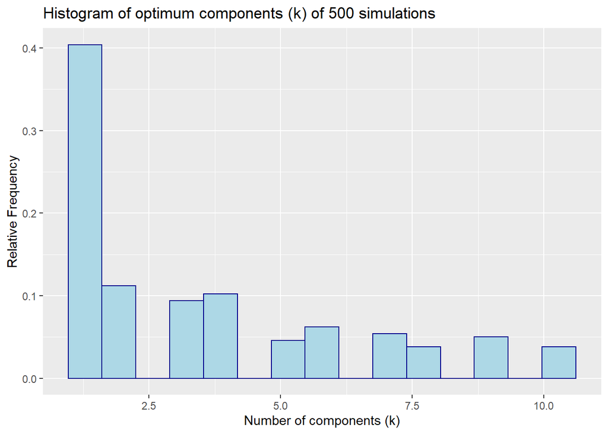

```r
ggplot2::ggplot(data.frame(best_k_n1_10cv), ggplot2::aes(x=best_k_n1_10cv))+
  ggplot2::geom_histogram(ggplot2::aes(y=..count../sum(..count..)), color="darkblue", fill="lightblue", bins =15)+
  ggplot2::labs(title = paste("Histogram of optimum components (k) of ", M, " simulations", sep=""), y = "Relative Frequency", x = "Number of components (k)")
```

Increasing the number of folds does not make a huge difference, at least when taking a small sample size. With the previous information, we get that the distribution remains asymmetric, and the mean number of components is 3.

Now, the second run is made with a sample size of 1000.

```r
tictoc::tic()
# Define the desired number of iterations
M <- 500

# Define the seed for replicability
seed <- 1234

# Define the sample size
n <- 1000

# Define the maximum number of components
k_max <- 10

# Define the number of folds
n_folds <- 10


# Pre-allocate memory for the optimum component in each iteration
best_k_n2_10cv <- rep(NA,M)

# Loop over desired number of iterations
for(i in 1:M){
  # Simulate from The Bart
  set.seed(seed)
  XX <- rnormmix(n,
                 lambda = c(0.5, rep(0.1,5)), mu = c(0, ((0:4)/2)-1), sigma = c(1, rep(0.1,5)) )

  # Set the possible components to check
  k <- 1:k_max
  # Pre-allocate memory for the optimum component in each iteration
  log_like_cross <- rep(NA,k_max)
  for(j in 1:k_max){
    log_like_cross[j] <- cross_val(XX, n_folds, seed, j)
    seed <- seed + 100
  }

  best_k_n2_10cv[i] <- which.max(log_like_cross)

  seed <- seed + 100
}
tictoc::toc()
```

```
## 3380.11 sec elapsed
```

```r
summary(best_k_n2_10cv)
```

```
##    Min. 1st Qu.  Median    Mean 3rd Qu.    Max.
##     2.0     7.0     9.0     8.2    10.0    10.0
```

```
## [1] "Standard deviation: 1.93"
```

```
## [1] "Coefficient of variation (CV): 23.48%"
```

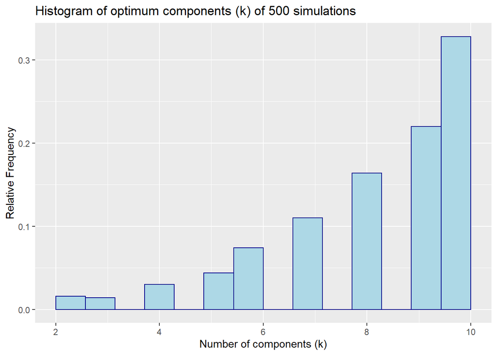

```r
ggplot2::ggplot(data.frame(best_k_n2_10cv), ggplot2::aes(x=best_k_n2_10cv))+
  ggplot2::geom_histogram(ggplot2::aes(y=..count../sum(..count..)), color="darkblue", fill="lightblue", bins =15)+
  ggplot2::labs(title = paste("Histogram of optimum components (k) of ", M, " simulations", sep=""), y = "Relative Frequency", x = "Number of components (k)")
```

When we increased the sample size, the distribution completely changes. Now the average number of components is 8, and the variation is perhaps one of the smallest (22%).

### h)

Now we define a function that provides a way to compute the Wasserstein based score using some parameters.

```r
wass_score <- function(seed, k_max, M, Z, n, p) {
  # seed: Seed for replicability
  # k_max: Maximum number of components to be considered
  # M: Number of iterations for the simulation
  # Z: Maximum number of iterations for the EM algorithm
  # n: Sample size
  # p: Proportion to split the data in train

  best_M <- rep(NA,M)

  for (i in 1:M) {

    # Update the seed
    seed <- seed + 100
    set.seed(seed)

    # Create dataset
    XX <- rnormmix(n, lambda=c(0.5,rep(0.1,5)), mu=c(0, ((0:4)/2)-1), sigma=c(1,rep(0.1,5)) )

    # Split data into training sample and test sample according to parameter "p"
    trainIndex <- createDataPartition(XX, p=p, list=FALSE)

    train_sample <- XX[trainIndex]
    test_sample <- XX[-trainIndex]

    scores_k <- rep(NA,k_max)

    for (k in 1:k_max) {

      # Update the seed
      seed <- seed + 100
      set.seed(seed)

      ps <- rep(1,k) / k

      # Define values for mu and sigma
      mus <- round(runif(k),0)
      sigmas <- round(runif(k),1) + 0.1

      # Fit the training data to estimate the parameters
      fit <- handmade.em(train_sample, p=ps, mu=mus, sigma=sigmas, n_iter=Z, plot_flag=F)

      est_ps <- fit$parameters[1:k]
      est_mus <- fit$parameters[(k+1):(k+k)]
      est_sigmas <- fit$parameters[(k+k+1):(k+k+k)]

      if ( sum(is.na(est_ps)) == 0 & sum(is.na(est_sigmas)) == 0 ) {

        quantiles = seq(0, 1, .01)

        inv_F_k <- dmixnorm(quantiles, mean=est_mus, sd=est_sigmas, pro=est_ps)


        ecdf_F_test <- ecdf(test_sample)
        inv_F_test <- quantile(ecdf_F_test, probs=quantiles)

        F_diff <- inv_F_k - inv_F_test
        scores_k[k] <- sum(abs(F_diff))

      } else {
        scores_k[k] <- 10000
      }


    }
    best_M[i] <- which.min(scores_k)
  }

  return(best_M)
}
```

So, we take the sample size equals to 50 to evaluate the performance of this measurement.

```r
tictoc::tic()

# Define the desired number of iterations
M <- 500

# Set number of iterations for the handmade EM function
Z <- 15

# Define the seed for replicability
seed <- 1234

# Define the maximum number of components
k_max <- 10

# Define the sample size
n <- 50

p <- 0.5

best_k_n1_wass <- wass_score(seed, k_max, M, Z, n, p)

tictoc::toc()
```

```
## 22.36 sec elapsed
```

```r
summary(best_k_n1_wass)
```

```
##    Min. 1st Qu.  Median    Mean 3rd Qu.    Max.
##   1.000   3.000   5.000   5.314   8.000  10.000
```

```
## [1] "Standard deviation: 2.75"
```

```
## [1] "Coefficient of variation (CV): 51.75%"
```

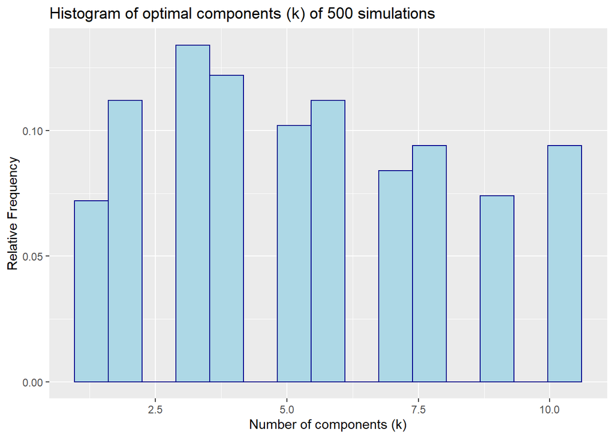

```r
ggplot2::ggplot(data.frame(best_k_n1_wass), ggplot2::aes(x=best_k_n1_wass))+
  ggplot2::geom_histogram(ggplot2::aes(y=..count../sum(..count..)), color="darkblue", fill="lightblue", bins =15)+
  ggplot2::labs(title = paste("Histogram of optimal components (k) of ", M, " simulations", sep=""), y = "Relative Frequency", x = "Number of components (k)")
```

```r
tictoc::tic()

# Define the desired number of iterations
M <- 500

# Set number of iterations for the handmade EM function
Z <- 15

# Define the seed for replicability
seed <- 1234

# Define the maximum number of components
k_max <- 10

# Define the sample size
n <- 1000

p <- 0.5

best_k_n2_wass <- wass_score(seed, k_max, M, Z, n, p)

tictoc::toc()
```

```
## 194.81 sec elapsed
```

```r
summary(best_k_n2_wass)
```

```
##    Min. 1st Qu.  Median    Mean 3rd Qu.    Max.
##   2.000   5.000   6.000   6.428   8.000  10.000
```

```
## [1] "Standard deviation: 2.17"
```

```
## [1] "Coefficient of variation (CV): 33.75%"
```

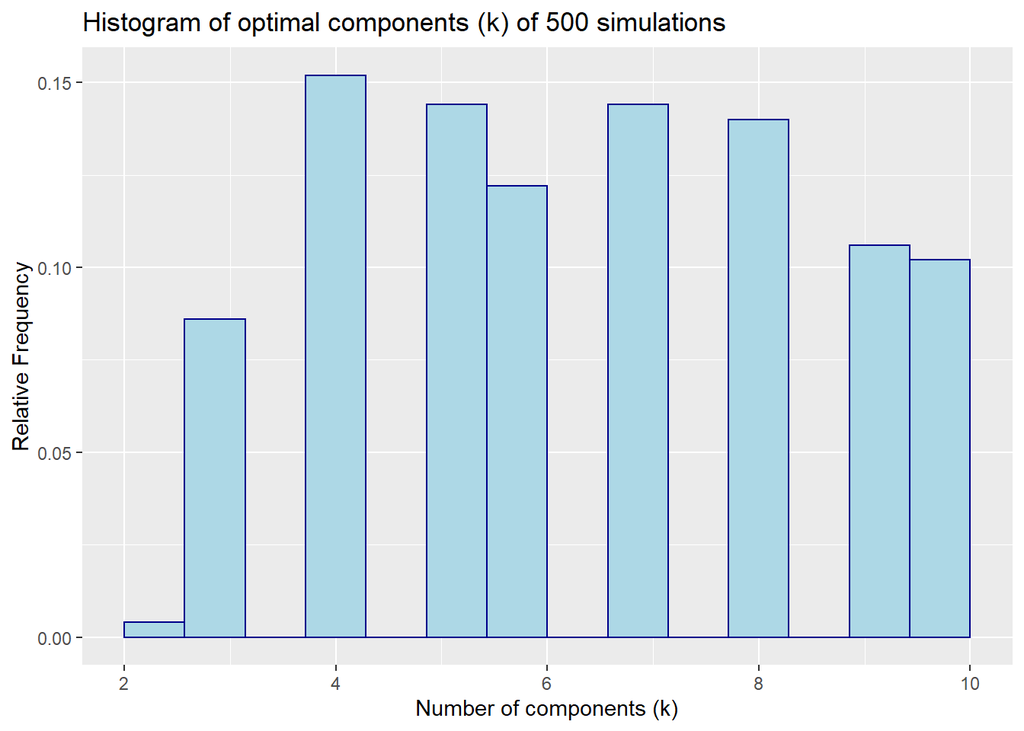

```r
ggplot2::ggplot(data.frame(best_k_n2_wass), ggplot2::aes(x=best_k_n2_wass))+
  ggplot2::geom_histogram(ggplot2::aes(y=..count../sum(..count..)), color="darkblue", fill="lightblue", bins =15)+
  ggplot2::labs(title = paste("Histogram of optimal components (k) of ", M, " simulations", sep=""), y = "Relative Frequency", x = "Number of components (k)")
```

Finally, taking a large sample size, the Wasserstein based score generates better results. We obtained a mean of a solid 6 (the same than the real data) and with a variation of only 35%.

## Question 4

Finally we want to analyze the distribution of the chosen components in each iteration. To achieve that we use an Mean Squared Error (MSE) metric (as a function) to compare the performance of each the simulations against the real value of 6 components.

```r
# Function to calculate Mean Squared Error
mse_func <- function(y, true_value){
  # y: vector corresponding to the result of iterations
  # true_value: True number of components
  return(var(y) + (mean(y) - true_value)^2)
}
```

Once we have defined the function to calculate the MSE, we can apply it to each one of the methods exposed before, for the first sample size of n = 50.

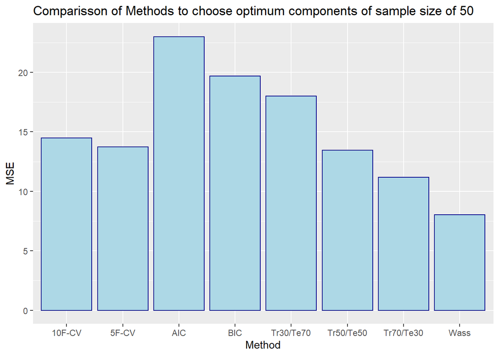

```r
# Pre-allocate vector to store MSE by method
mse_vector <- rep(NA, 8)
# Mean squared error for selection with AIC
mse_vector[1] <- mse_func(y = best_k_n1_aic, true_value = 6)
# Mean squared error for selection with BIC
mse_vector[2] <- mse_func(y = best_k_n1_bic, true_value = 6)
# Mean squared error for selection with split train = 50% / test = 50%
mse_vector[3] <- mse_func(y = best_k_n1_Tr50_Te50, true_value = 6)
# Mean squared error for selection with split train = 70% / test = 30%
mse_vector[4] <- mse_func(y = best_k_n1_Tr70_Te30, true_value = 6)
# Mean squared error for selection with split train = 30% / test = 70%
mse_vector[5] <- mse_func(y = best_k_n1_Tr30_Te70, true_value = 6)
# Mean squared error for 5-fold cross-validation
mse_vector[6] <- mse_func(y = best_k_n1_5cv, true_value = 6)
# Mean squared error for 10-fold cross-validation
mse_vector[7] <- mse_func(y = best_k_n1_10cv, true_value = 6)
# Mean squared error for Wasserstein based score
mse_vector[8] <- mse_func(y = best_k_n1_wass, true_value = 6)

mse_vector <- data.frame(mse_vector)
mse_vector$Methods <- c("AIC", "BIC", "Tr50/Te50", "Tr70/Te30", "Tr30/Te70", "5F-CV", "10F-CV","Wass")

# PLot MSE
ggplot2::ggplot(data=mse_vector, ggplot2::aes(x=Methods, y=mse_vector))+
  geom_bar(stat="identity", fill="lightblue", color="darkblue")+
  ggplot2::labs(title = paste("Comparisson of Methods to choose optimum components of sample size of ", 50, sep=""), y = "MSE", x = "Method")
```

When the sample size is 50, we can see that the best way to select the optimum number of components is by Wasserstein based score approach since it’s the one that generates the lowest MSE. Moreover, AIC and BIC methods are the worsts.

Finally we apply the MSE the methods exposed before, for the second sample size of n = 1000.

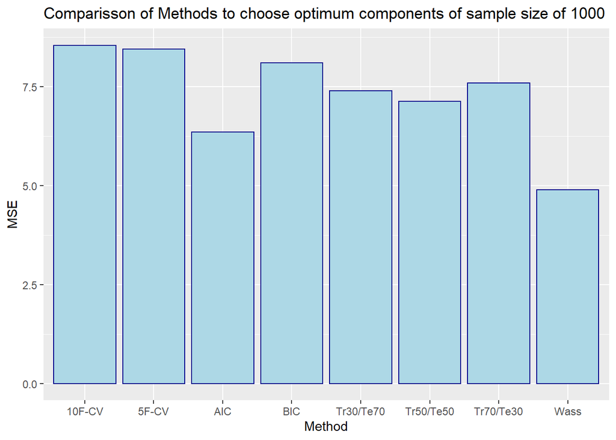

```r
# Pre-allocate vector to store MSE by method
mse_vector <- rep(NA, 8)
# Mean squared error for selection with AIC
mse_vector[1] <- mse_func(y = best_k_n2_aic, true_value = 6)
# Mean squared error for selection with BIC
mse_vector[2] <- mse_func(y = best_k_n2_bic, true_value = 6)
# Mean squared error for selection with split train = 50% / test = 50%
mse_vector[3] <- mse_func(y = best_k_n2_Tr50_Te50, true_value = 6)
# Mean squared error for selection with split train = 70% / test = 30%
mse_vector[4] <- mse_func(y = best_k_n2_Tr70_Te30, true_value = 6)
# Mean squared error for selection with split train = 30% / test = 70%
mse_vector[5] <- mse_func(y = best_k_n2_Tr30_Te70, true_value = 6)
# Mean squared error for 5-fold cross-validation
mse_vector[6] <- mse_func(y = best_k_n2_5cv, true_value = 6)
# Mean squared error for 10-fold cross-validation
mse_vector[7] <- mse_func(y = best_k_n2_10cv, true_value = 6)
# Mean squared error for Wasserstein based score
mse_vector[8] <- mse_func(y = best_k_n2_wass, true_value = 6)

mse_vector <- data.frame(mse_vector)
mse_vector$Methods <- c("AIC", "BIC", "Tr50/Te50", "Tr70/Te30", "Tr30/Te70", "5F-CV", "10F-CV","Wass")

# PLot MSE
ggplot2::ggplot(data=mse_vector, ggplot2::aes(x=Methods, y=mse_vector))+
  geom_bar(stat="identity", fill="lightblue", color="darkblue")+
  ggplot2::labs(title = paste("Comparisson of Methods to choose optimum components of sample size of ", 1000, sep=""), y = "MSE", x = "Method")
```

When the sample size is 1000, we can see that the best way to select the optimum number of components is by using Wasserstein based score since it’s the one that generates the lowest MSE. Moreover, all the methods of train/test splitting have almost the same gain.

## Main conclusions of simulations

To sum up the main results of our experimentation, we conclude that:

- Using a small sample size, the Bart distribution can not be held.
- When the sample size tends to infinite, a reasonably asymptotic for the Bart distribution is defined.
- When dealing with small samples sizes, the best approach to find the optimum number of components is the Wasserstein based score.
- Alos for large sample sizes, the best metric to define the number of components is using Wasserstein based score. Besides, all the methods of train/test splitting have almost the same performance
- a good method of selection that seem good for small samples size is the Wasserstein based score, returning the same component (on average) that the target value.

## Bibliography

To deal with the challenges in the homework, we gave a look to the next sources, in order to understand certain topics to solve each question.

- https://people.eecs.berkeley.edu/~pabbeel/cs287-fa13/slides/Likelihood_EM_HMM_Kalman.pdf
- https://en.wikipedia.org/wiki/Wasserstein_metric

We hope that the way to solve this challenge has been clear and concise. See you in a next homework!

[figure not shown]